# 🌈 Objetivo da Aula

- Entender o que é um intervalo de confiança (IC)
- Compreender o papel da média amostral, erro padrão e grau de confiança
- Interpretar corretamente um IC

# 🔍 O que é um Intervalo de Confiança?

Um intervalo de confiança é um intervalo de valores plausíveis para o parâmetro de interesse (como a média populacional), baseado em uma amostra.

Exemplo: "Com 95% de confiança, a média do colesterol da população está entre 180 e 200 mg/dL."

# 🔢 Como interpretar?

Um IC de 95% significa que, se repetíssemos o estudo muitas vezes, cerca de 95% dos intervalos construídos conteriam o verdadeiro parâmetro.

Ou seja, a média amostral é uma estimativa imparcial da média populacional, ou seja, em média, ela não tende nem a subestimar nem a superestimar. Por isso, os intervalos de confiança, baseados na média amostral, são corretos em média – se o processo for repetido muitas vezes.

# ❌ Erros comuns de interpretação (Misconceptions)

**Erro: Ignorar a margem de erro**

Um erro comum é ignorar a margem de erro ou a largura do intervalo de confiança (estimativa intervalar) e focar apenas na estimativa pontual ou no centro do intervalo. No entanto, a margem de erro reflete a precisão e a variabilidade da estimativa e é afetada pelo tamanho da amostra, pelo nível de confiança e pela variabilidade populacional. Um intervalo de confiança estreito indica uma estimativa mais precisa, enquanto um intervalo de confiança amplo indica uma estimativa mais incerta. Portanto, você deve sempre relatar e comparar os intervalos de confiança com suas margens de erro, e não apenas as estimativas pontuais.

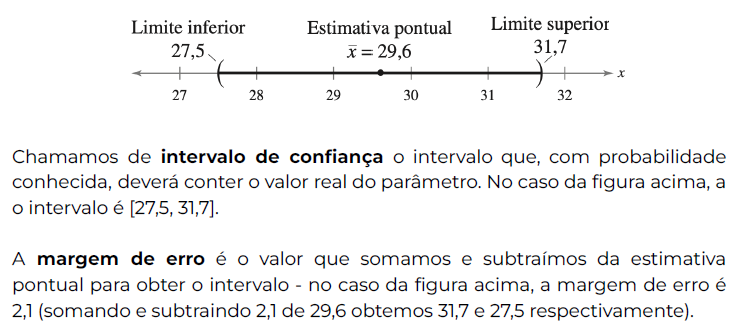

**Erro: Confundir confiança com probabilidade**

Um dos erros mais comuns é confundir o nível de confiança com a probabilidade de o parâmetro populacional estar dentro do intervalo de confiança. Por exemplo, se você tem um intervalo de confiança de 95% para o peso médio de uma população, isso não significa que há uma chance de 95% de que o peso médio verdadeiro esteja dentro desse intervalo. Em vez disso, isso significa que, se você repetir o processo de amostragem muitas vezes, 95% dos intervalos de confiança obtidos conterão o verdadeiro peso médio. O nível de confiança reflete a confiabilidade do método de amostragem, e não a incerteza sobre o parâmetro populacional.

**Erro: Comunicar mal os resultados obtidos com base nos intervalos de confianç**

Um erro comum é interpretar ou comunicar mal os resultados com base nos intervalos de confiança, como fazer afirmações causais, generalizar além do escopo dos dados ou usar linguagem vaga ou enganosa. Um bom analista deve ser claro, honesto e técnico, evitando exageros. O IC é uma ferramenta poderosa, mas deve ser interpretado com respeito às limitações da amostra, suposições do modelo e objetivos da análise.

Isso porque há incerteza inerente quando você usa dados de amostra para fazer inferências sobre uma população inteira. Os intervalos de confiança reconhecem essa incerteza, ao invés de tentar ocultá-la — e isso é uma das grandes forças da estatística.

Se você tem um intervalo de confiança não deve usar termos como "garantido", "comprovado" ou "exato" para descrever o resultado, pois eles implicam certeza e ignoram a incerteza e a variabilidade da estimativa. Para evitar esse erro, você deve usar uma linguagem clara, precisa e cautelosa para comunicar os resultados com base nos intervalos de confiança e reconhecer as limitações e suposições da análise. Exemplo:

- ❌ “Está comprovado que a média é X.”
- ✅ “Estimamos que a média esteja entre Y e Z, com 95% de confiança.”
- ✅ “A estimativa da média é de X, com um intervalo de confiança de 95% entre Y e Z.”
- ✅ “Com base nessa amostra, podemos inferir com 95% de confiança que...”

# ⚖️ Estrutura do Intervalo

A forma geral de um intervalo de confiança para a média é:

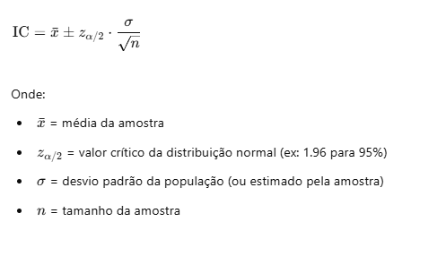

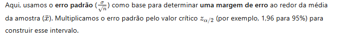

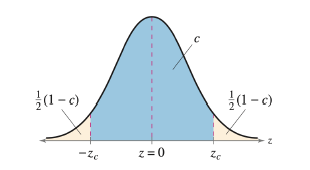

**Erro padrão**

Ou seja, a fórmula do intervalo de confiança usa o erro padrão para definir a faixa de valores plausíveis para a média populacional. A Precisão da estimativa melhora com menor erro padrão, o que acontece se:

- O desvio padrão da população for menor
- O tamanho da amostra for maior

**Nível de confiança**

Além do erro padrão, o tamanho do intervalo de confiança também depende do valor crítico (𝑧 𝛼/2), que está relacionado ao nível de confiança que você escolhe. O número 𝑧 𝛼/2 é retirado da distribuição normal padrão que representa quantos desvios padrão queremos considerar para "capturar" a média populacional com uma certa confiança. Em outras palavras, o valor de nos diz quantos erros padrão para cada lado da média você precisa incluir para capturar a área desejada sob a curva normal (a sua confiança).

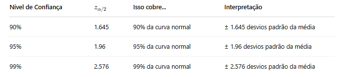

Se você usa 95% de confiança, o valor crítico 𝑧 𝛼/2 = 1.96, ou seja, você está dizendo: “Quero um intervalo que fique 1.96 desvios padrão para cima e para baixo da média — isso cobre 95% das possíveis amostras”.

🎯 Por que não usar 100% de confiança?

Porque o intervalo teria que ser infinitamente largo. Para garantir 100% de certeza de que o verdadeiro valor está incluído, o intervalo teria que conter todos os valores possíveis — e isso não é útil para análises práticas. Exemplo do texto: Para garantir que a altura de toda mulher brasileira esteja dentro de um intervalo com 100% de confiança, precisaríamos de um intervalo gigante — o que não ajuda na tomada de decisão.

❗ E se usarmos um nível muito baixo, como 5%?

Nesse caso, o intervalo será estreito, mas a probabilidade de conter o parâmetro verdadeiro será muito baixa. Isso significa que não podemos confiar nesse intervalo para representar bem a população. Exemplo: Se o intervalo de 5% for de 1,62 a 1,64m para altura de mulheres, isso é muito estreito e não representará a maioria da população, mesmo que pareça preciso.

✅ Então, qual o nível de confiança ideal?

A prática mais comum é usar 95% de confiança, podendo variar entre 90% e 99%, dependendo da área de estudo e do grau de precisão necessário.

**Margem de Erro**

Assim, é que temos a margem de erro. Ela representa o quanto estamos dispostos a "errar" para mais ou para menos em torno da média amostral, ao construir um intervalo de confiança.

# 👨‍💻 Demonstração do cálculo do Intervalo de Confiança da Média quando desvio padrão é conhecido

Quando você calcula um intervalo de confiança na média, você calcula a média de uma amostra para estimar a média da população. É claro que se você já soubesse a média da população, não haveria necessidade de um intervalo de confiança. No entanto, para explicar como os intervalos de confiança são construídos, vamos trabalhar de trás para frente e começar assumindo características da população. Então mostraremos como os dados da amostra podem ser usados para construir um intervalo de confiança.

Suponha que os pesos de crianças de 10 anos sejam normalmente distribuídos com uma média de 90 e um desvio padrão de 36. Qual é a distribuição amostral da média para um tamanho de amostra de 9?

```python
from scipy.stats import norm
from numpy import linspace
import plotly.graph_objects as go
```

```python
mu = 90 #média da população
sigma = 36 #desvio padrão da população
N = 9 #tamanho da amostra
```

```python
X = linspace(mu - 4 * sigma, mu + 4 * sigma, 1000)
go.Figure(
    {
        'data': [
            {'x': X, 'y': norm(mu, sigma).pdf(X), 'name': 'population'},
            {'x': X, 'y': norm(mu, sigma / (N ** 0.5)).pdf(X), 'name': 'sample means (n=9)'}
        ]
    }
)
```

[interactive chart not shown]

Lembre-se da aula sobre a distribuição amostral da média que a média da distribuição amostral é $\mu$ e o erro padrão da média é

$\sigma_M=\frac{\sigma}{\sqrt{N}}$

Para o exemplo presente, a distribuição amostral da média tem uma média de 90 e um desvio padrão de 36/3 = 12.

```python
sigma / (N ** 0.5)
```

```
12.0
```

```python
norm(mu, sigma / (N ** 0.5)).interval(0.95)
```

```
(np.float64(66.48043218551935), np.float64(113.51956781448065))
```

Esses limites foram calculados adicionando e subtraindo 1,96 desvios-padrão de/para a média de 90, como segue:

$90 - (1,96)(12) = 66,48$

$90 + (1,96)(12) = 113,52$

O valor de 1,96 é baseado no fato de que 95% da área de uma distribuição normal está dentro de 1,96 desvios-padrão da média; 12 é o erro-padrão da média.

```python
 z = norm().interval(0.95)[1]
 z
```

```
np.float64(1.959963984540054)
```

```python
lb = mu - z * sigma / (N ** 0.5)
ub = mu + z * sigma / (N ** 0.5)
lb, ub
```

```
(np.float64(66.48043218551935), np.float64(113.51956781448065))
```

```python
import matplotlib.pyplot as plt
import numpy as np
from scipy.stats import norm, t, uniform
import pandas as pd
```

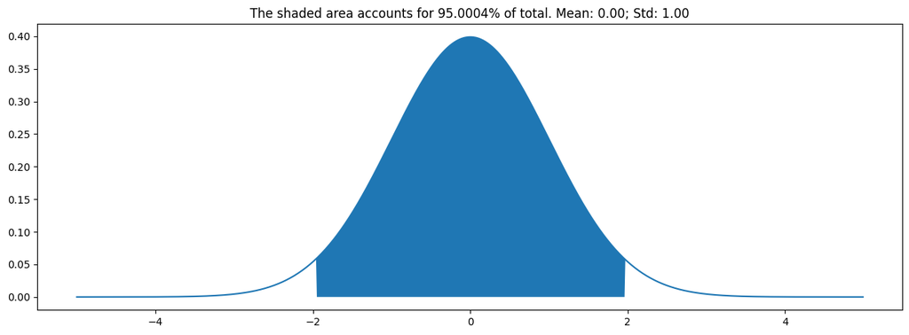

```python
def area_between(mean, std, between):
    dist = norm(mean, std)
    fig, ax = plt.subplots(1, 1, figsize=(15, 5))
    x_axis = np.arange(mean - 5 * std, mean + 5 * std, 0.01)
    n = pd.Series(dist.pdf(x_axis), index=x_axis)
    _ = n.plot(ax=ax, legend=False)
    lb = mean - between * std
    ub = mean + between * std
    where = np.logical_and(x_axis > lb, x_axis < ub)
    _ = ax.fill_between(x_axis, n, 0, where=where, interpolate=True)
    area = dist.cdf(ub) - dist.cdf(lb)
    title = ('The shaded area accounts for {:.4f}% of total. '
             'Mean: {:.2f}; Std: {:.2f}').format(area * 100, mean, std)
    _ = plt.title(title)

area_between(0, 1, 1.96)
```

```python
1.96 * (sigma / (N ** 0.5))
```

```
23.52
```

Agora considere a probabilidade de que uma média amostral calculada em uma amostra aleatória esteja dentro de 23,52 unidades da média populacional de 90. Como 95% da distribuição está dentro de 23,52 de 90, a probabilidade de que a média de qualquer amostra dada esteja dentro de 23,52 de 90 é 0,95.

Isso significa que se calcularmos repetidamente a média ($M$) de uma amostra e criarmos um intervalo variando de $M - 23,52$ a $M + 23,52$, esse intervalo conterá a média populacional 95% do tempo. Em geral, você calcula o intervalo de confiança de 95% para a média com a seguinte fórmula:

Limite inferior = $M - Z_{.95}\sigma_M$

Limite superior = $M + Z_{.95}\sigma_M$

onde $Z_{.95}$ é o número de desvios-padrão que se estendem da média de uma distribuição normal necessária para conter 0,95 da área e $\sigma_M$ é o erro-padrão da média.

```python
mean = 90
std = 12
z = 1.96

dist = norm(90, 12)
lower_limit = mean - z * std
upper_limit = mean + z * std
area = dist.cdf(upper_limit) - dist.cdf(lower_limit)

print(f'{area*100:.2f}% da probabilidade está dentro do intervalo {lower_limit:.2f} to {upper_limit:.2f}.')
```

```
95.00% da probabilidade está dentro do intervalo 66.48 to 113.52.
```

```python
norm(mu, sigma / (N ** 0.5)).interval(0.95)
```

```
(np.float64(66.48043218551935), np.float64(113.51956781448065))
```

```python
mean = 90
std = 12
area = 0.95

dist = norm(mean, std)
lower_limit = dist.ppf((1 - area) / 2)
upper_limit = dist.ppf(area + (1 - area) / 2)
z = (upper_limit - mean) / std

msg = 'mean +/- {:.2f} stds (Z={:.2f}) define the range {:.2f} to {:.2f}.'
print(msg.format(z, z, lower_limit, upper_limit))
```

```
mean +/- 1.96 stds (Z=1.96) define the range 66.48 to 113.52.
```

Se você observar atentamente esta fórmula para um intervalo de confiança, notará que **você precisa saber o desvio padrão da população ($\sigma$) para estimar a média**. Isso pode parecer irreal, e é. No entanto, calcular um intervalo de confiança quando $\sigma$ é conhecido é mais fácil do que quando $\sigma$ tem que ser estimado, e serve a um propósito pedagógico. Mais adiante nesta seção, mostraremos como calcular um intervalo de confiança para a média quando $\sigma$ tem que ser estimado.

Suponha que os cinco números a seguir foram amostrados de uma distribuição normal com um desvio padrão de 2,5: 2, 3, 5, 6 e 9. Para calcular o intervalo de confiança de 95%, comece calculando a média e o erro padrão:

$M = \frac{(2 + 3 + 5 + 6 + 9)}{5} = 5$.

$\sigma_M = \frac{2,5}{\sqrt{5}} = 1,118$.

```python
ser = pd.Series([2, 3, 5, 6, 9])
m = ser.mean()
sigma_m = 2.5 / (m ** 0.5)
m, sigma_m
```

```
(np.float64(5.0), np.float64(1.118033988749895))
```

$Z_{.95}$ pode ser encontrado usando a calculadora de distribuição normal e especificando que a área sombreada é 0,95 e indicando que você deseja que a área esteja entre os pontos de corte.

```python
upper_limit = norm(m, sigma_m).ppf(0.975)
z = (upper_limit - m) / sigma_m
z
```

```
np.float64(1.9599639845400545)
```

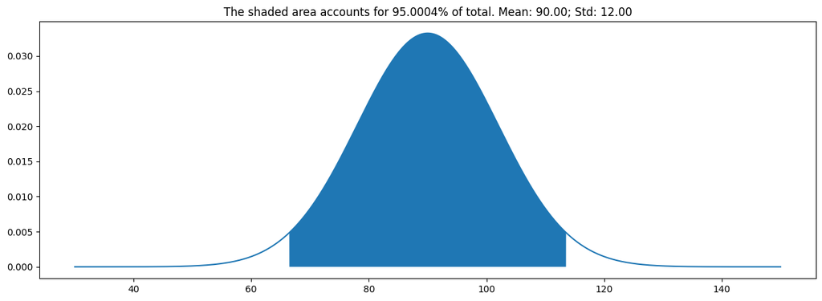

```python
area_between(90, 12, 1.96)
```

# 🔢 Simulação

Esta simulação ilustra intervalos de confiança.

Para cada execução da simulação, 100 experimentos de amostra são conduzidos e um intervalo de confiança na média é computado para cada experimento. Em cada experimento, as pontuações são amostradas de uma população com uma média de 50 e um desvio padrão de 10.

Portanto, o parâmetro sendo estimado é sempre 50. Ambos os intervalos de confiança de 95% e 99% são computados para cada experimento.

Se o intervalo de confiança de 95% contiver a média populacional de 50, então o intervalo de confiança é mostrado como uma linha laranja.

Se o intervalo não contiver 50, ele é mostrado como uma linha vermelha.

Você pode escolher o tamanho da amostra para cada experimento.

```python
import matplotlib.pylab as plt
import numpy as np
from scipy.stats import norm
import pandas as pd
```

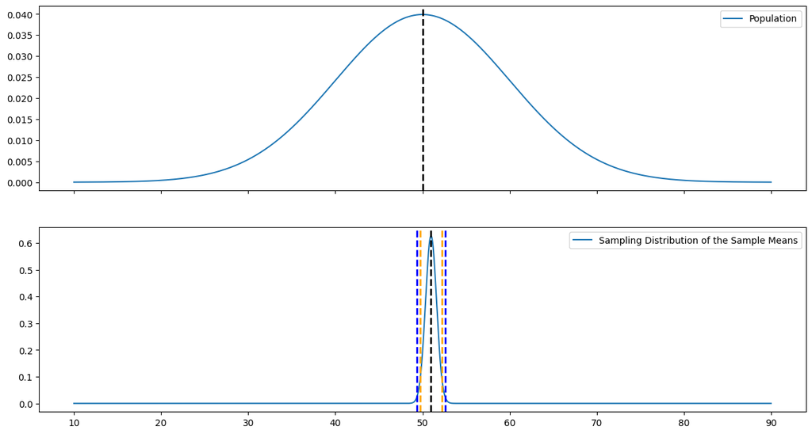

|  | count | mean | std | 95% LB | 95% UB | 99% LB | 99% UB |
| --- | --- | --- | --- | --- | --- | --- | --- |
| 0 | 2.0 | 50.978627 | 0.899983 | 49.731337 | 52.225917 | 49.33941 | 52.617844 |

```python
figure, ax = plt.subplots(2, figsize=(15, 8), sharex=True)

mean, std = 50, 10
n = 2 #Aqui você tirou uma única amostra com n = 2 (tamanho pequeno).

x_axis = np.arange(mean - 4 * std, mean + 4 * std, 0.01)

this_norm = norm(mean, std)

ser = pd.Series(this_norm.pdf(x_axis),
                index=x_axis,
                name='Population')

_ = ser.plot(ax=ax[0], legend=True) #Distribuição azul em forma de sino: representa a população original, que é uma distribuição normal com média 50 e desvio padrão 10.

ax[0].axvline(x=this_norm.ppf(0.5), color='k', linestyle='--', linewidth=2)
sample = pd.Series(norm(mean, std).rvs(n))
mean_M = sample.mean()
s_M = sample.std() / (n ** 0.5)
this_norm = norm(mean_M, s_M)
ser = pd.Series(this_norm.pdf(x_axis),
                index=x_axis,
                name='Sampling Distribution of the Sample Means') #A curva mostra a distribuição normal simulada com a média da amostra e seu erro padrão.

_ = ser.plot(ax=ax[1], legend=True)

#Intervalo de Confiança de 95% (vermelho ou laranja)
#São as duas linhas vermelhas ou laranja tracejadas ao redor da média da amostra.
#Se a média real da população (50) cai fora do intervalo → vermelho (erro de cobertura).
#Se ela cai dentro → laranja (acerto).
#Como n é pequeno (n = 2), o erro padrão é grande, e o intervalo pode não cobrir o valor verdadeiro.
lb1, ub1 = this_norm.ppf(0.025), this_norm.ppf(0.975)
color1 = 'red' if mean < lb1 or mean > ub1 else 'orange'

#Intervalo de Confiança de 99% (azul ou branco)
#São as linhas azuis/brancas — intervalo mais largo.
#Maior confiança → maior margem de erro.
#Novamente, depende se o valor 50 cai dentro do intervalo.
lb2, ub2 = this_norm.ppf(0.005), this_norm.ppf(0.995)
color2 = 'white' if mean < lb1 or mean > ub1 else 'blue'

ax[1].axvline(x=lb1, color=color1, linestyle='--', linewidth=2)
ax[1].axvline(x=ub1, color=color1, linestyle='--', linewidth=2)
ax[1].axvline(x=mean_M, color='k', linestyle='--', linewidth=2)  #Linha preta tracejada: é a média da amostra.
ax[1].axvline(x=lb2, color=color2, linestyle='--', linewidth=2)
ax[1].axvline(x=ub2, color=color2, linestyle='--', linewidth=2)
plt.show()
pd.DataFrame([sample.count(), sample.mean(), sample.std(),
              lb1, ub1, lb2, ub2],
             index=['count', 'mean', 'std',
                    '95% LB', '95% UB', '99% LB', '99% UB']).T
```

- Média amostral ≈ 50.97 → próxima de 50
- Mas com n = 2, o desvio é muito pequeno para capturar a variabilidade real. Amostras pequenas (n = 2) produzem intervalos instáveis.
- Os limites do IC são baseados nesse erro padrão pequeno, o que pode gerar intervalos enganadores com n pequeno.
- Os intervalos de 99% são mais largos e tendem a cobrir mais frequentemente o valor verdadeiro.

```python
m = 1000
n = 100

mean, std = 50, 10 #uma população normal com média 50 e desvio padrão 10
df = []

#calcular a média da amostra, o desvio padrão da amostra, Intervalos de confiança de 95% e 99%

for _ in range(m):
    sample = pd.Series(norm(mean, std).rvs(n)) #Cria uma amostra de tamanho n da distribuição normal N(50, 10)
    mean_M = sample.mean() #Calcula a média da amostra
    s_M = sample.std() / (n ** 0.5) #Calcula o erro padrão da média
    this_norm = norm(mean_M, s_M) #Cria uma nova distribuição normal centrada na média da amostra com o erro padrão calculado
    lb1, ub1 = this_norm.ppf(0.025), this_norm.ppf(0.975) #O .ppf() fornece os percentis da distribuição normal
    color1 = 'red' if mean < lb1 or mean > ub1 else 'orange' #se a média verdadeira (50) está fora do intervalo de 95%, o IC é vermelho (erro). caso contrário, é laranja (acerto).
    lb2, ub2 = this_norm.ppf(0.005), this_norm.ppf(0.995) #O .ppf() forn  ece os percentis da distribuição normal
    color2 = 'white' if mean < lb2 or mean > ub2 else 'blue' #mesma lógica vale para o IC de 99% (azul e branco).

    df.append([sample.count(), sample.mean(), sample.std(),
               lb1, ub1, color1, lb2, ub2, color2])


df = pd.DataFrame(df, columns=['count', 'mean', 'std',
                               '95% LB', '95% UB', '95%parecer', '99% LB', '99% UB', '99%parecer'])

df.head()
```

|  | count | mean | std | 95% LB | 95% UB | 95%parecer | 99% LB | 99% UB | 99%parecer |
| --- | --- | --- | --- | --- | --- | --- | --- | --- | --- |
| 0 | 100 | 48.987503 | 9.863702 | 47.054253 | 50.920753 | orange | 46.446781 | 51.528224 | blue |
| 1 | 100 | 51.898942 | 9.607045 | 50.015995 | 53.781888 | red | 49.424331 | 54.373553 | blue |
| 2 | 100 | 51.703981 | 10.257982 | 49.693453 | 53.714508 | orange | 49.061699 | 54.346262 | blue |
| 3 | 100 | 49.479550 | 9.541632 | 47.609424 | 51.349675 | orange | 47.021788 | 51.937311 | blue |
| 4 | 100 | 50.187472 | 10.125004 | 48.203007 | 52.171936 | orange | 47.579443 | 52.795500 | blue |

```python
df.shape
```

```
(1000, 9)
```

```python
# Filtra o DataFrame onde '95%parecer' é 'blue'
filtered_df = df[(df['95%parecer'] == 'orange')]
filtered_df.shape
```

```
(938, 9)
```

```python
# Filtra o DataFrame onde '95%parecer' não é 'blue'
filtered_df = df[(df['95%parecer'] != 'orange')]
filtered_df.shape
```

```
(62, 9)
```

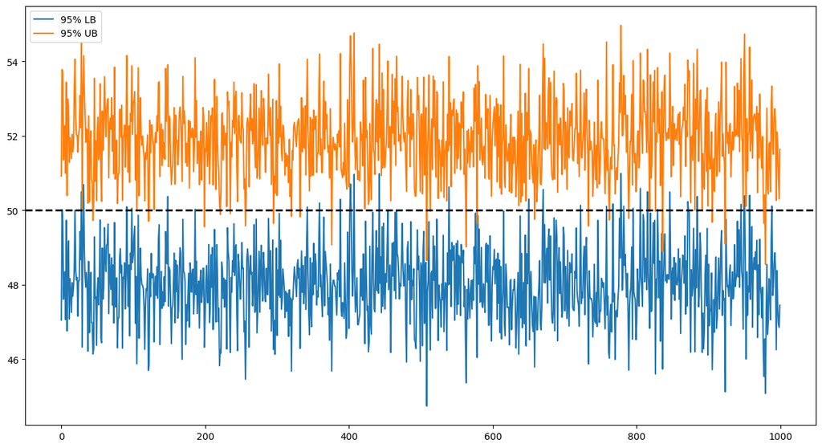

```python
figure, ax = plt.subplots(1, figsize=(15, 8))
_ = df[['95% LB', '95% UB']].plot(ax=ax)
_ = ax.axhline(y=mean, color='k', linestyle='--', linewidth=2)
```

O número de intervalos azuis (corretos) deve ser: ~990 em 1000 para o IC de 99%.

```python
# Filtra o DataFrame onde '99%parecer' é 'blue'
filtered_df = df[(df['99%parecer'] == 'blue')]
filtered_df.shape
```

```
(987, 9)
```

```python
# Filtra o DataFrame onde '95%parecer' não é 'blue'
filtered_df = df[(df['99%parecer'] != 'blue')]
filtered_df.shape
```

```
(13, 9)
```

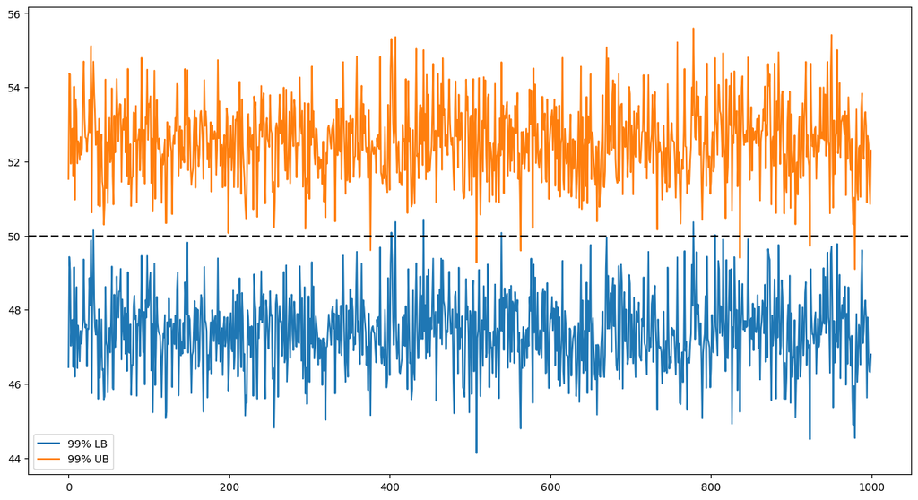

```python
figure, ax = plt.subplots(1, figsize=(15, 8))
_ = df[['99% LB', '99% UB']].plot(ax=ax)
_ = ax.axhline(y=mean, color='k', linestyle='--', linewidth=2)
```

Essa simulação mostra que:

- Nem todos os intervalos de confiança incluem a média verdadeira.
- A frequência com que isso acontece depende do nível de confiança (ex: aproximadamente 95% dos ICs de 95% deveriam conter o valor verdadeiro).
- Quanto maior o nível de confiança, mais largos os intervalos, por isso maior a margem de erro

# ✅ Quando usar z ou t?

Para usar fórmulas padrão de intervalo de confiança, a distribuição dos dados precisa ser aproximadamente normal.

Entretanto, graças ao Teorema do Limite Central, quando o tamanho da amostra for n ≥ 30, a distribuição das médias amostrais será aproximadamente normal, mesmo que a distribuição original dos dados não seja. Isso permite o uso de intervalos de confiança simétricos.

No entanto, **para usar a distribuição Z precisamos saber previamente do desvio padrão populacional. Ocorre que, na prática, quase nunca conhecemos o desvio padrão da população.**

Alternativamente, devemos usar a distribuição t em vez da distribuição normal quando a variância não for conhecida e tiver que ser estimada a partir de dados de amostra.

Quando o tamanho da amostra é grande, digamos 30 ou mais (100 em algumas literaturas, por segurança), a distribuição t é muito semelhante à distribuição normal padrão. No entanto, com tamanhos de amostra menores, a distribuição t é leptocúrtica, o que significa que tem relativamente mais pontuações em suas caudas do que a distribuição normal (Ela é mais larga - tem caudas mais pesadas-, ou seja, mais conservadora)

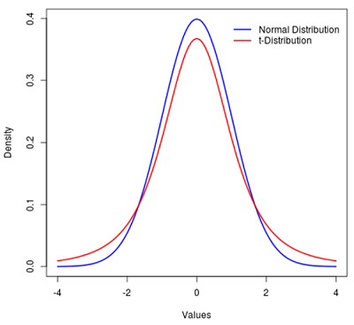

```python
import numpy as np
```

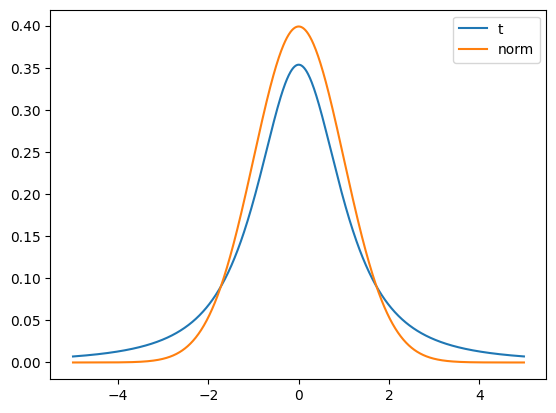

```python
def compare_normal_and_t(deg_free):
    x_axis = np.arange(-5, 5, 0.01)
    df = pd.DataFrame(list(zip(t(deg_free).pdf(x_axis),
                               norm().pdf(x_axis))),
                      index=x_axis, columns=['t', 'norm'])
    _ = df.plot(),

compare_normal_and_t(2)
```

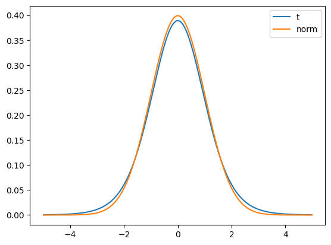

```python
#Quando n aumenta, s tende a se aproximar de 𝜎 e a distribuição t se aproxima da normal.

compare_normal_and_t(10)
```

```python
import numpy as np
from scipy.stats import norm, t
from itertools import zip_longest, product
import pandas as pd
```

```
Uma comparação entre distribuições t com 2, 4 e 10 df
e a distribuição normal padrão. A distribuição com o
pico mais baixo é a distribuição de 2 df, o próximo mais baixo é o de 4 df,
o menor depois disso é o de 10 df, e o mais alto é a distribuição normal padrão.
```

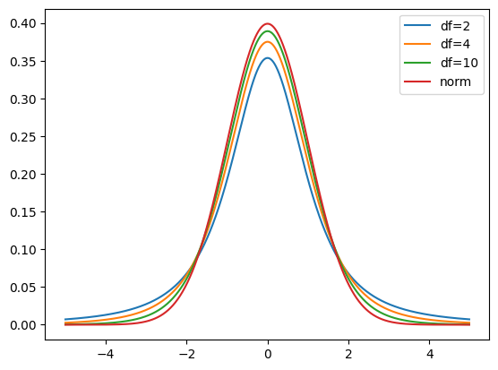

```python
def compare_normal_and_t(deg_frees):
    x_axis = np.arange(-5, 5, 0.01)
    df = [t(deg_free).pdf(x_axis) for deg_free in deg_frees] + \
         [norm().pdf(x_axis)]
    columns = ['df={}'.format(deg_free) for deg_free in deg_frees] + \
              ['norm']
    df = pd.DataFrame(list(map(list, zip_longest(*df))),
                      columns=columns,
                      index=x_axis)
    _ = df.plot()

compare_normal_and_t([2, 4, 10])
print('Uma comparação entre distribuições t com 2, 4 e 10 df \n'
'e a distribuição normal padrão. A distribuição com o \n'
'pico mais baixo é a distribuição de 2 df, o próximo mais baixo é o de 4 df, \n'
'o menor depois disso é o de 10 df, e o mais alto é a distribuição normal padrão.')
```

Como resultado, você tem que se estender mais longe da média para conter uma determinada proporção da área. Lembre-se de que com uma distribuição normal, 95% da distribuição está dentro de 1,96 desvios-padrão da média. Usando a distribuição t, se você tiver um tamanho de amostra de apenas 5, 95% da área está dentro de 2,78 desvios-padrão da média. Portanto, o erro padrão da média seria multiplicado por 2,78 em vez de 1,96.

```python
from scipy.stats import norm
```

```python
#Isso calcula a área central entre -1.96 e +1.96 sob a curva normal padrão, ou seja, o intervalo que cobre 95% dos dados.
#É o clássico intervalo de confiança de 95% da distribuição normal.

norm().cdf(1.96) - norm().cdf(-1.96)
```

```
np.float64(0.950004209703559)
```

```python
from scipy.stats import t
```

```python
#Com graus de liberdade = 4, o valor crítico t necessário para conter 95% da área central é maior do que o z padrão (2.78 em vez de 1.96).
#Isso acontece porque a distribuição t tem caudas mais largas (maior incerteza com amostras pequenas).

t.cdf(2.78, 4) - t.cdf(-2.78, 4)
```

```
np.float64(0.950181491538601)
```

A distribuição t distribui-se também de forma simétrica com média 0 e o valor t é dado pela seguinte fórmula:

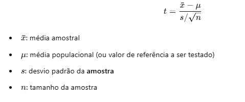

Essa fórmula parece com a do valor z, mas usa o desvio padrão da amostra (𝑠) ao invés do desvio da população (𝜎). Isso é fundamental quando o desvio padrão populacional não é conhecido, o que é muito comum na prática.

Os valores de t a serem usados em um intervalo de confiança podem ser consultados em uma tabela da distribuição t. Uma versão pequena dessa tabela é mostrada na Tabela 1. A primeira coluna, df, representa graus de liberdade e, para intervalos de confiança na média, df é igual a N - 1, onde N é o tamanho da amostra.

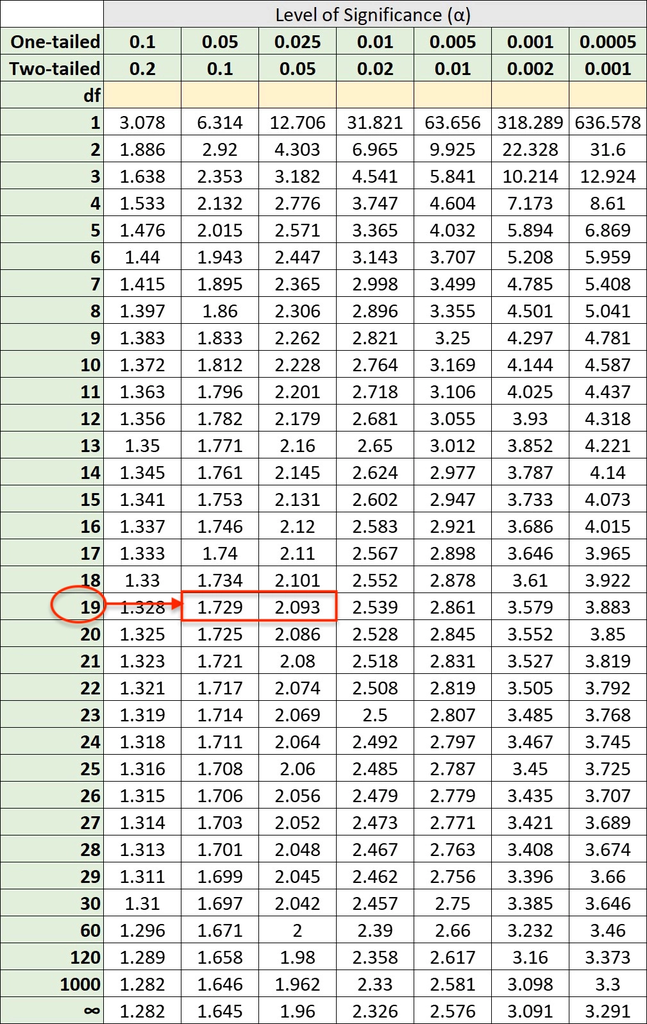

# 👨‍💻 Demonstração do cálculo do Intervalo de Confiança da Média quando desvio padrão é desconhecido

Suponha que os cinco números a seguir sejam amostrados de uma distribuição normal: 2, 3, 5, 6 e 9, e que o desvio padrão seja desconhecido. Os primeiros passos são calcular a média amostral e o desvio padrão:

```python
import pandas as pd
```

```python
ser = pd.Series([2, 3, 5, 6, 9])
sample_mean = ser.mean()
sample_std = ser.std()
sample_mean, sample_std
```

```
(np.float64(5.0), 2.7386127875258306)
```

O próximo passo é estimar o erro padrão da média. Se soubéssemos a variância populacional, poderíamos usar a seguinte fórmula:

$\sigma_m = \frac{\sigma}{\sqrt{N}}$

Em vez disso, calculamos uma estimativa do erro padrão ($s_M$):

$s_m = \frac{s}{\sqrt{N}}=1,225$

```python
sigma_m = sample_std / (ser.size ** 0.5)
sigma_m
```

```
1.224744871391589
```

O próximo passo é encontrar o valor de t. Como você pode ver na Tabela 1, o valor para o intervalo de 95% para df = N - 1 = 4 é 2,776.

```python
t_stat = t(4).ppf(0.975)
t_stat
```

```
np.float64(2.7764451051977987)
```

E então, de forma mais geral, a fórmula para o intervalo de confiança de 95% na média é:

Limite inferior = $M - (t_{CL})(s_M)$

Limite superior = $M + (t_{CL})(s_M)$

onde $M$ é a média amostral, $t_{CL}$ é o $t$ para o nível de confiança desejado (0,95 no exemplo acima) e $s_M$ é o erro padrão estimado da média.

Dessa forma, calcule para o nosso exemplo:

Limite inferior = $5 - (2,776)(1,225) = 1,60$

Limite superior = $5 + (2,776)(1,225) = 8,40$

```python
df = ser.size - 1
t_stat = 2.776

lower_limit = sample_mean - t_stat * sigma_m
upper_limit = sample_mean + t_stat * sigma_m
area = t(df, loc=sample_mean, scale=sigma_m).cdf(upper_limit) - \
       t(df, loc=sample_mean, scale=sigma_m).cdf(lower_limit)

msg = '{:.2f}% da probabilidade está dentro do intervalo {:.2f} to {:.2f}.'
print(msg.format(area*100, lower_limit, upper_limit))
```

```
95.00% da probabilidade está dentro do intervalo 1.60 to 8.40.
```

# 🤔 Curiosidade sobre a distribuição t de Student

Nascido em Canterbury em 1876, Gosset estudou em Winchester e Oxford, onde se formou em química em 1897 e em matemática em 1899. Foi contratado pela cervejaria Guinness em Dublin, onde passou o resto da vida, principalmente em St. James Gate, em Dublin, e pelos últimos dois anos em Park Royal, em Londres. A formação acadêmica de Gosset pode parecer incompatível com seu emprego como cervejeiro, mas a Guinness percebeu, nessa época, que, para manter sua participação dominante no mercado como a maior cervejaria da Irlanda, teria que introduzir a produção de cerveja em escala industrial cuidadosamente controlada. Tal empreendimento exigiria um rigoroso controle de qualidade; daí a necessidade de químicos e estatísticos com formação universitária. Como qualquer cervejeiro amador pode atestar, a produção de cerveja tem um elemento de incerteza, sendo o sucesso dependente não apenas do procedimento correto, mas também de um elemento de sorte! Foi essa dependência da sorte para um produto bem-sucedido que a Guinness buscou eliminar por meio de procedimentos científicos. Cerveja, é claro, é uma combinação de produtos naturais: cevada maltada, lúpulo e levedura, todos misturados com água. Esses produtos naturais compartilham uma variabilidade inerente comum a todos os produtos agrícolas, cuja qualidade depende não apenas da variedade da cultura, mas também do clima, das condições do solo, etc. A tarefa de Gosset como Aprendiz de Cervejeiro não era apenas avaliar a qualidade desses produtos, mas também fazê-lo de maneira econômica. Isso exigia o uso de experimentos com pequenas amostras para tirar conclusões que pudessem ser aplicadas ao processo de fabricação de cerveja em larga escala. No entanto, Gosset descobriu que, ao usar pequenas amostras, a distribuição das médias se desviava da distribuição normal. Portanto, ele não podia usar métodos estatísticos convencionais baseados em uma distribuição normal para tirar suas conclusões.

Gosset, então, escreveu a Karl Pearson na UCL, e eles se encontraram em 12 de julho de 1905, enquanto Gosset estava de férias na Inglaterra. Esse encontro levou a um convite para Gossett visitar o departamento de Pearson na UCL em 1906/07 por um ano, onde trabalhou em seu problema de pequenas amostras. Em 1908, Gosset publicou o fruto de seu trabalho em um artigo intitulado " O erro provável de uma média" no periódico Biometrica (Student, 1908), do qual Pearson era editor. No entanto, o Guinness tinha uma política de não publicar dados da empresa e permitiu que Gosset publicasse suas observações sob o estrito entendimento de que ele o faria anonimamente e não utilizaria nenhum dado da empresa. Gosset concordou e publicou sob o pseudônimo "Student" – o nome sob o qual ele publicaria 19 de suas 21 publicações. O nome Student aparentemente veio da capa de um caderno que Gosset usava na época – The Student's Science Notebook (Ziliak, 2008).

O próprio Gosset não tinha pretensões acadêmicas e se apresenta como um homem pragmático. Ele desdenhava sua habilidade matemática, afirmando que os limites de suas capacidades " paravam em Matemática, Mods [exames finais] em Oxford, consequentemente, não tenho faculdade na área " (Gosset, 1962). Gosset claramente não era nenhum bobo, mas suas habilidades matemáticas não estavam no mesmo nível de Fisher ou Pearson. O fato de sua derivação de t ser incompleta e parcialmente adivinhada corrobora esse ponto, mas a distribuição t totalmente derivada de Fisher em 1925 mostrou que a intuição de Gosset estava correta. De fato, Fisher comenta que " qualquer analista capaz poderia ter lhe mostrado a demonstração de que ele precisava ". Os cálculos de Gosset frequentemente continham pequenos erros, e ele preferia fazê-los no verso de envelopes e pedaços de papel (McMullen, 1939), um amadorismo cativante reforçado apenas por comentários como " In a similar tedious way we find" (De forma similar e tediosa, encontramos ) durante uma derivação mais extensa (Student, 1908). No entanto, a distribuição t permitiu que Gosset prosseguisse com seu trabalho para a Guinness, e ele foi promovido a cervejeiro-chefe experimental e chefe de estatística, e finalmente, em 1935, promovido a Cervejeiro-Chefe, cargo que ocupou até sua morte, dois anos depois.

Em conclusão, fisiologistas (e muitos outros cientistas experimentais) têm uma dívida de gratidão com Gosset por tornar obsoleta a dependência de grandes tamanhos de amostra para determinar diferenças entre grupos de dados. A distribuição t permite aos experimentadores a liberdade de usar tamanhos de amostra pequenos, com a confiança de que não estão comprometendo a validade de quaisquer conclusões tiradas: de fato, a política de Redução, Refinamento e Substituição do Ministério do Interior em relação a experimentos com animais seria impossível sem a distribuição t.

O fato de Gosset, certamente o herói anônimo da estatística do século XX, ter feito um avanço tão enorme no campo da estatística se deve quase certamente à sua aplicação da teoria para resolver problemas práticos. Em uma carta a Fisher sobre suas distribuições t, Gosset lamentou que " você é o único homem que provavelmente as usará ". Uma olhada em qualquer edição do The Journal of Physiology servirá para ilustrar a ubiquidade do teste t de Student nas ciências biológicas e demonstrar o quão inconsciente Gosset estava do impacto revolucionário que seu trabalho teria em todos os campos da biologia e além.